# Theoretical Travel Cost of Goleta Beach

Author

Roxana Lagunas and Sophia Lecuona

```r
library(tidyverse)
library(here)
library(janitor)
library(broom)
library(tidymodels)
library(kableExtra)
library(patchwork)
library(ggplot2)
library(gtsummary)

# ---------- data directories ---------
# raw data directory
raw_data_dir <- here("beach_nourishment", "asbpa", "raw_data")

# intermediate data directory
int_dir <- here("beach_nourishment", "asbpa", "intermediate")

# output data directory
output_dir <- here("beach_nourishment", "asbpa", "output")
```

# Read in data on zip codes in Santa Barbara and Ventura counties

```r
# read in data
zip_codes <- read_csv(here("beach_nourishment", "asbpa", "raw_data", "zip_codes_sb_ventura.csv"))

zip_codes_mi <- read_csv(here("beach_nourishment", "asbpa", "raw_data", "zip_codes_sb_ventura_mi.csv"))

zip_codes_final <- read_csv(here("beach_nourishment", "asbpa", "raw_data", "zip_codes_sb_ventura_w_income.csv"))

# remove duplicates
zip_codes_clean <- zip_codes_final %>%
  select(-c(`...7`, `...8`)) %>%
  group_by(zip_code) %>%
  distinct(zip_code, .keep_all = TRUE)

# for santa barbara county
zip_codes_sb <- zip_codes_clean %>%
  filter(county == "Santa Barbara County")

# for ventura county
zip_codes_ventura <- zip_codes_clean %>%
  filter(county == "Ventura County")
```

# Random sample of zip codes to estimate travel cost, simulating a survey

For SB:

```r
# make a dataframe of random sample of zip codes for sb
print(unique(zip_codes_sb$zip_code))
```

```
 [1] 93463 93427 93013 93014 93429 93254 93117 93110 93111 93116 93118 93434
[13] 93436 93437 93438 93440 93441 93108 93150 93455 93457 93101 93102 93103
[25] 93105 93106 93107 93109 93120 93121 93130 93140 93160 93190 93454 93456
[37] 93458 93460 93464 93067
```

```r
# random sample (n = 200) of zip codes, used to estimate the travel cost method
set.seed(713)
n_samples <- 1000 # for the income sample

zip_codes_sample_sb <- data.frame(
  travel_method = sample(c("personal_vehicle","carpool","public_transportation","bicycle","walking"), 150, replace = TRUE, prob = c(0.35, 0.20, 0.35, 0.10, 0.05))
)  # the travel method used to get to the beach, used to estimate cost later
```

For Ventura:

```r
# make a dataframe of random sample of zip codes for ventura
# print(unique(zip_codes_ventura$zip_code))

# random sample (n = 200) of zip codes, used to estimate the travel cost method
set.seed(713)
n_samples <- 1000 # for the income sample

zip_codes_sample_ventura <- data.frame(travel_method = sample(c("personal_vehicle","carpool","public_transportation"), 50, replace = TRUE, prob = c(0.50, 0.35, 0.15)))
  # mutate(income = sample(rnorm(n_samples, mean = 102141, 20428.2), 50, replace = TRUE)) # the travel method used to get to the beach, used to estimate cost later

# the median household income of ventura is $102,141, of which the standard deviation is $1,528.  Source: https://datausa.io/profile/geo/ventura-county-ca/
# source for income: https://datausa.io/profile/geo/ventura-county-ca
```

Join the two dataframes together and sample zip codes:

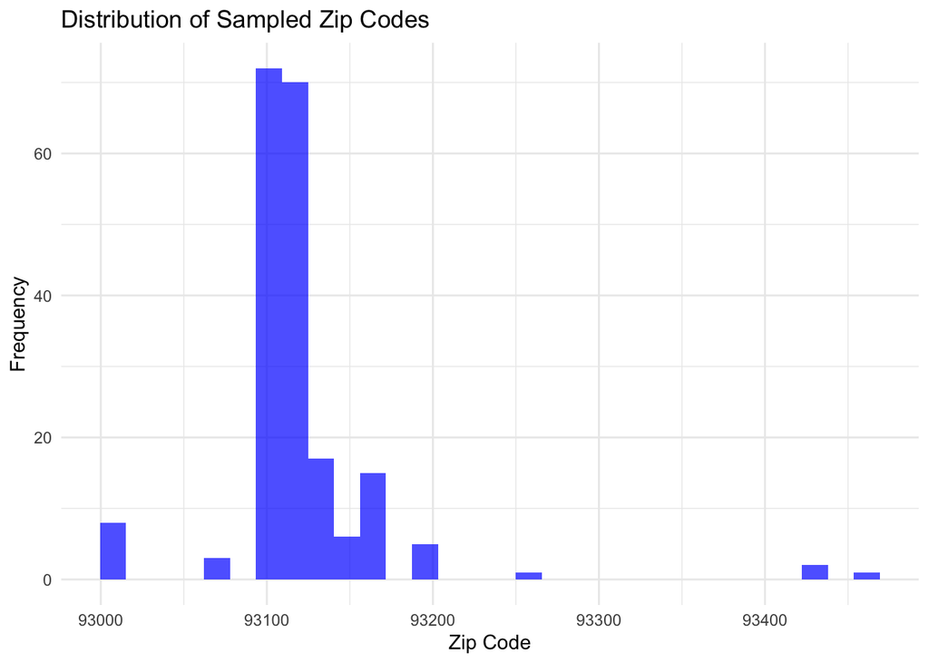

```r
zip_codes_weighted <- zip_codes_clean %>%
  mutate(
    sampling_weight = if_else(distance_from_gb <= 30,
                               # for distances under 30 miles, use an inverse power law
                               1 / (distance_from_gb + 1), # inverse power law
                               # for distances over 30 miles, use an extremely low weight
                               0.001
    ))

set.seed(713)
zip_codes_sample <- bind_rows(zip_codes_sample_sb, zip_codes_sample_ventura) %>% # joining ventura and sb samples
  mutate(zip_code = sample(zip_codes_weighted$zip_code, 200, replace = TRUE, prob = zip_codes_weighted$sampling_weight)) %>%  #sample zip codes based on which ones are closer, using the function we made
  left_join(zip_codes_clean, by = "zip_code") # join with zip_codes_clean

# hist(zip_codes_sample$zip_code)

ggplot(zip_codes_sample, aes(x = zip_code)) +
  geom_histogram(bins = 30, fill = "blue", alpha = 0.7) +
  labs(title = "Distribution of Sampled Zip Codes",
       x = "Zip Code",
       y = "Frequency") +
  theme_minimal()
```

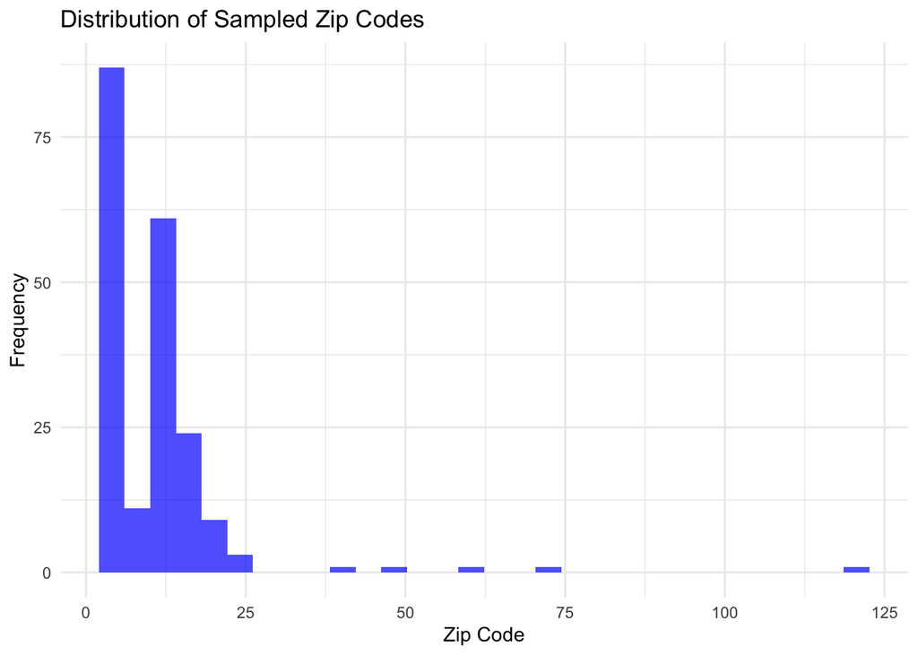

```r
ggplot(zip_codes_sample, aes(x = distance_from_gb)) +
  geom_histogram(bins = 30, fill = "blue", alpha = 0.7) +
  labs(title = "Distribution of Sampled Zip Codes",
       x = "Zip Code",
       y = "Frequency") +
  theme_minimal()
```

```r
summary_stats <- zip_codes_sample %>%
  summarize(
    mean_distance = mean(distance_from_gb),
    median_distance = median(distance_from_gb),
    max_distance = max(distance_from_gb),
    prop_under_20_miles = mean(distance_from_gb <= 20)
  )
print(summary_stats)
```

```
  mean_distance median_distance max_distance prop_under_20_miles
1       10.6835            10.8        118.8               0.915
```

# Calculate travel cost

```r
# calculate travel cost
travel_cost <- zip_codes_sample %>% # so each zip code has its respective city and county
  mutate(travel_cost = case_when(
    travel_method == "personal_vehicle" ~ (4.5/21 * distance_from_gb) + (median_income*(1/525600) * time_to_gb), # cost of gas (average price of gas in SB is $4.50/gallon) * (average US mid-size miles per gallon) * distance to gb plus the time it takes to get to gb # income $/ year * (year / minutes in a year) * time to gb (minutes/trip)
    travel_method == "carpool" ~ (2.25/21 * distance_from_gb) + (median_income*(1/525600) * time_to_gb), # half the cost of gas (assumption!!) * distance to gb plus the time it takes to get to gb
    travel_method == "public_transportation" ~ 6 + (median_income*(1/525600) * time_to_gb), # flat fee to get to gb (SB day pass, would also apply to those coming from Ventura) using the bus plus the time it takes to get to gb
    travel_method == "bicycle" ~ median_income*(1/525600) * time_to_gb * 3, # time it takes to get to gb... distance in miles to gb * (60min/10 miles) using the average speed of a bike is 10 miles per hour
    # https://cyced.cc/blog/how-long-does-it-take-to-cycle-10-miles-with-examples/#:~:text=How%20long%20to%20cycle%2010,10%20miles%20will%20be%20reduced.
    travel_method == "walking" ~ median_income*(1/525600) * time_to_gb * 9 # also only time it takes to get to gb... distance in miles to gb * (60min/3 miles) using the average speed of a walker is 3 miles per hour
    # https://www.healthline.com/health/exercise-fitness/average-walking-speed#average-speed-by-age
  ))
```

# Demand curve and consumer surplus

Now, based on the travel cost and the number of respondents based on zip code sample frequency, we can determine the demand curve and consumer surplus.

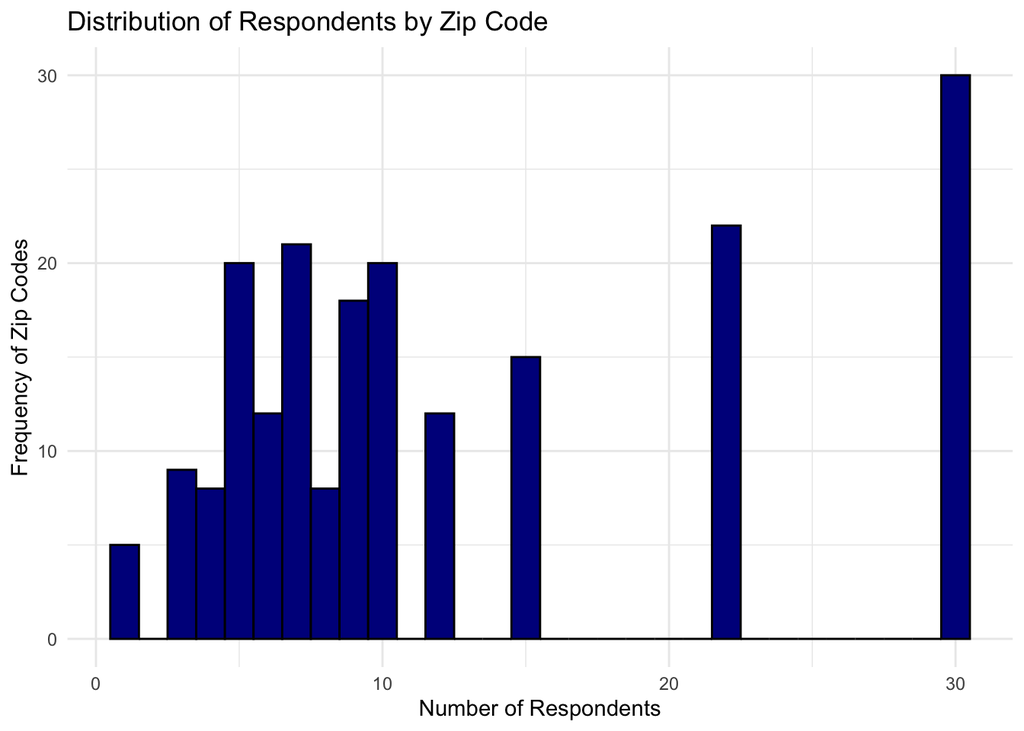

```r
# determine zip code representation
visitor_frequency <- travel_cost %>%
  group_by(zip_code) %>%
  summarize(
    visitor_count = n() # number of respondents from this zip code
  ) %>%
  ungroup() %>%
  mutate(
    visitor_frequency = visitor_count / nrow(travel_cost) # frequency of respondents from this zip code
  )

travel_cost_w_frequency <- travel_cost %>%
  left_join(visitor_frequency, by = "zip_code") %>%
  mutate(travel_cost_visit = travel_cost * visitor_frequency) # $/trip * # of trips = $!

# distribution of visitors by zip code
ggplot(travel_cost_w_frequency, aes(x = visitor_count)) +
  geom_histogram(binwidth = 1, fill = "darkblue", color = "black") +
  labs(title = "Distribution of Respondents by Zip Code",
       x = "Number of Respondents",
       y = "Frequency of Zip Codes") +
  theme_minimal()
```

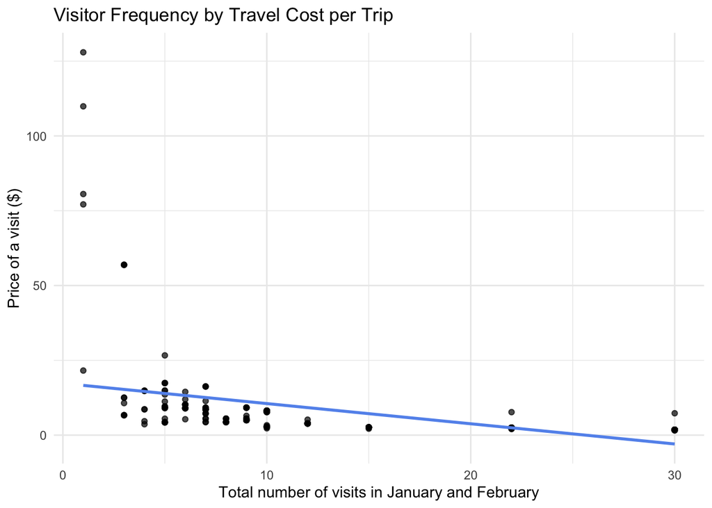

```r
# plotting visitor frequency by mean travel cost (which is the demand curve, we will see this later too)
ggplot(travel_cost_w_frequency, aes(x = visitor_count, y = travel_cost)) +
  geom_point(alpha = 0.7) +
  geom_smooth(method = "lm", color = "cornflowerblue", se = FALSE) +
  labs(title = "Visitor Frequency by Travel Cost per Trip",
       x = "Total number of visits in January and February",
       y = "Price of a visit ($)") +
  theme_minimal()
```

Linear regression model:

```r
# linear regression model
travel_cost_model <- lm(travel_cost ~ visitor_count, data = travel_cost_w_frequency)
summary(travel_cost_model)
```

```
Call:
lm(formula = travel_cost ~ visitor_count, data = travel_cost_w_frequency)

Residuals:
    Min      1Q  Median      3Q     Max
-10.962  -5.302  -3.037   0.223 111.328

Coefficients:
              Estimate Std. Error t value Pr(>|t|)
(Intercept)    17.3013     1.7316   9.992  < 2e-16 ***
visitor_count  -0.6754     0.1107  -6.098 5.52e-09 ***
---
Signif. codes:  0 '***' 0.001 '**' 0.01 '*' 0.05 '.' 0.1 ' ' 1

Residual standard error: 14.04 on 198 degrees of freedom
Multiple R-squared:  0.1581,    Adjusted R-squared:  0.1539
F-statistic: 37.19 on 1 and 198 DF,  p-value: 5.518e-09
```

```r
# create table of findings
tbl_regression(travel_cost_model,
               conf.level = 0.95,
               exponentiate = FALSE,
               intercept = TRUE,
               estimate_fun = ~style_sigfig(.x, digits = 4)) %>%
  bold_p(t = 0.05) %>%
  add_glance_source_note() %>%
  add_global_p()
```

| **Characteristic** | **Beta** | **95% CI**<sup>1</sup> | **p-value** |
| --- | --- | --- | --- |
| (Intercept) | 17.30 | 13.89, 20.72 | <0.001 |
| visitor_count | -0.6754 | -0.8938, -0.4570 | <0.001 |

R² = 0.158; Adjusted R² = 0.154; Sigma = 14.0; Statistic = 37.2; p-value = <0.001; df = 1; Log-likelihood = -811; AIC = 1,628; BIC = 1,638; Deviance = 39,040; Residual df = 198; No. Obs. = 200  
<sup>1</sup> CI = Confidence Interval

$$Travel\ Cost = β0 + β1 * Visits$$
$$Travel\ Cost = 17.30 - 0.6754 * Visits$$

To find WTP, we want to plot the demand curve, which is typically the inverse of our regression model:

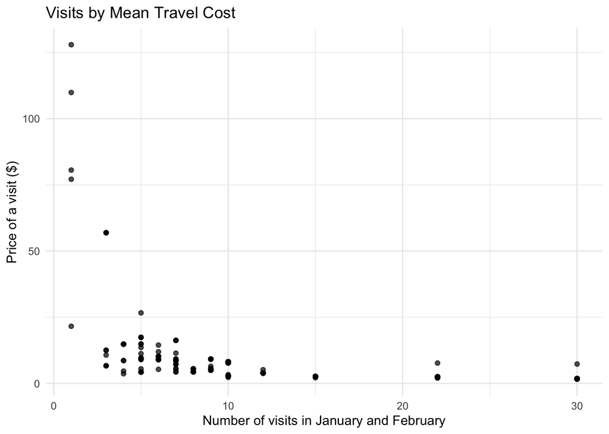

```r
# plot the demand curve, visitor frequency by mean travel cost
travel_cost_demand_curve_plot <- ggplot(travel_cost_w_frequency, aes(x = visitor_count, y = travel_cost)) +
  geom_point(alpha = 0.7) +
  labs(title = "Visits by Mean Travel Cost",
       x = "Number of visits in January and February",
       y = "Price of a visit ($)") +
  theme_minimal()
travel_cost_demand_curve_plot
```

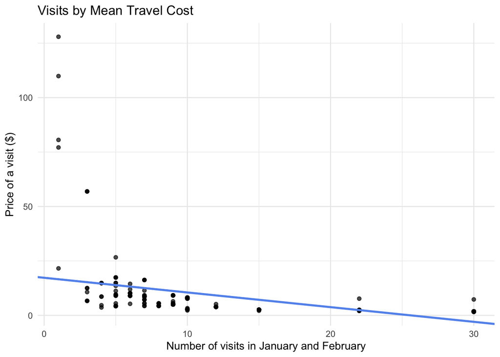

```r
# now, plot $$Travel \ Cost = 13.52771 - 0.43740 * Visits$$
travel_cost_demand_curve_plot +
  geom_abline(intercept = 17.30, slope = -0.6754, color = "cornflowerblue", lwd = 1)
```

Calculate the consumer surplus by integrating this curve:

```r
demand_goleta_beach <- function(x){
  17.30 - 0.6754 * x
}

x_int <- 17.30/0.6754

consumer_surplus <- integrate(demand_goleta_beach, 0, x_int)
consumer_surplus
```

```
221.565 with absolute error < 2.5e-12
```

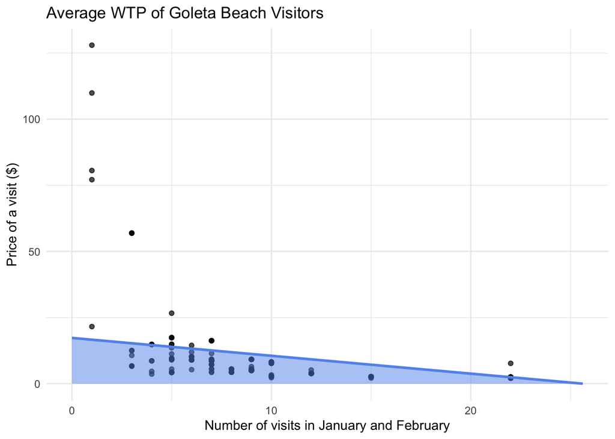

```r
# $221.565 with absolute error < 2.5e-12 average willingness to pay for two months of goleta beach usage

# create a data frame for the demand curve
demand_curve_data <- data.frame(
  x = seq(0, x_int, length.out = 100),
  y = demand_goleta_beach(seq(0, x_int, length.out = 100))
)

ggplot() +
  geom_point(data = travel_cost_w_frequency, aes(x = visitor_count, y = travel_cost), alpha = 0.7) +
  geom_line(data = demand_curve_data, aes(x = x, y = y), color = "cornflowerblue", lwd = 1) +
  geom_ribbon(data = demand_curve_data, aes(x = x, ymin = 0, ymax = y),
              fill = "cornflowerblue", alpha = 0.5) +
    labs(title = "Average WTP of Goleta Beach Visitors",
       x = "Number of visits in January and February",
       y = "Price of a visit ($)") +
  theme_minimal() +
  coord_cartesian(xlim = c(0, x_int), ylim = c(0, max(travel_cost_w_frequency$travel_cost)))
```

Now, assuming that is a value determined over two months, we can divide the WTP by the number of days surveyed to get a daily value:

$$Consumer\ Surplus = \int_{0}^{25.62} 17.30 - 0.6754 * Visits$$

```r
consumer_surplus_daily <- consumer_surplus$value / (31 + 28)
consumer_surplus_daily # $3.755339/day
```

```
[1] 3.755339
```

# Water Quality Evaluation for Goleta Beach

Data found from https://www.waterboards.ca.gov/water_issues/programs/beaches/beach_water_quality/, specifically https://www.waterboards.ca.gov/water_issues/programs/beaches/search_beach_mon.html. The data is from the California State Water Resources Control Board. The data is from the Santa Barbara County Beaches. The data is from 2000 to 2024, though data was downloaded from 2010 to 2024.

## Goleta Beach Quality Setup

```r
library(tidyverse)
library(readxl)
library(lubridate)
library(here)
library(janitor)
library(tictoc)
library(ggplot2)
library(plotly) # for interactive plots

# ---------- data directories ---------
# raw data directory
raw_data_dir <- here("beach_nourishment", "wrcb_water_qual", "raw_data")

# intermediate data directory
int_dir <- here("beach_nourishment", "wrcb_water_qual", "intermediate")

# output data directory
output_dir <- here("beach_nourishment", "wrcb_water_qual", "output")
```

Read in Data:

```r
# read in the data
all_beach_qual_raw <- read_csv(here(raw_data_dir, "beach_monitoring_wrcb-AllResultData.csv")) %>%
  clean_names()
```

### Data Cleaning

```r
# filter for goleta beach
goleta_beach_qual <- all_beach_qual_raw %>%
  filter(station_description %in% "Goleta Beach")

# convert to lubridate
goleta_beach_qual_mdy <- goleta_beach_qual %>%
  mutate(sample_date = mdy(sample_date)) %>%
  select(sample_date, parameter, result, unit, station_description)
```

### Plotting beach quality

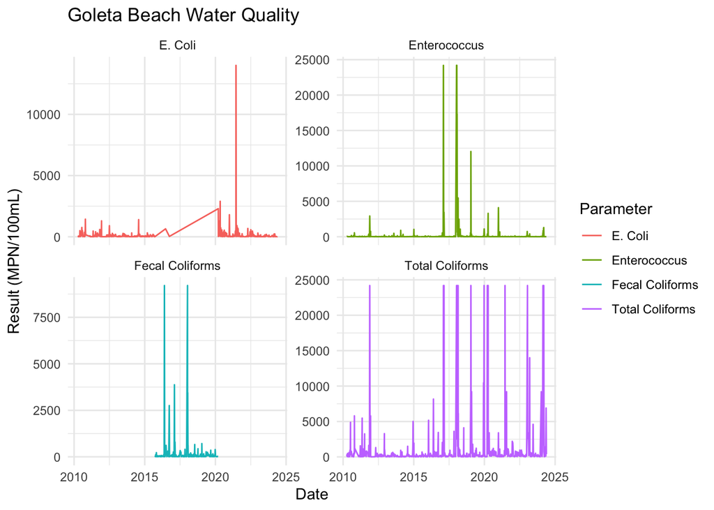

```r
# plot the beach quality for all parameters
total_gb_quality_plot <- goleta_beach_qual_mdy %>%
  ggplot(aes(x = sample_date, y = result, color = parameter)) +
  geom_line() +
  facet_wrap(~parameter, scales = "free_y") +
  labs(title = "Goleta Beach Water Quality",
       x = "Date",
       y = "Result (MPN/100mL)",
       color = "Parameter") +
  theme_minimal()
total_gb_quality_plot
```

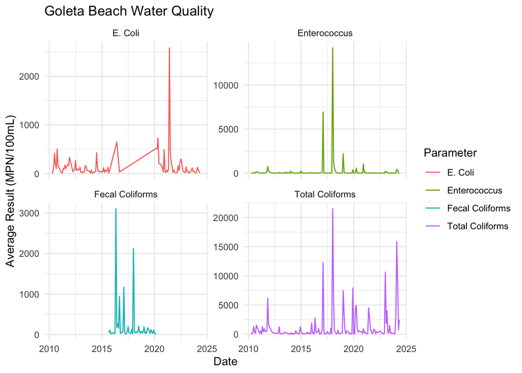

```r
## save plot
# ggsave(here(output_dir, "total_gb_quality_plot.png"), plot = total_gb_quality_plot)

# average the parameter result levels (MPN/100mL) by month per year
monthly_avg_gb_total <- goleta_beach_qual_mdy %>%
  mutate(month = month(sample_date), year = year(sample_date)) %>%
  group_by(parameter, month, year) %>%
  summarise(avg_result = mean(result, na.rm = TRUE))

# return the dates to the original format
monthly_avg_gb_total_mdy <- monthly_avg_gb_total %>%
  mutate(date = make_date(year, month, 1)) %>%
  ungroup()# giving the first day of the month, though it is the average results for each month of each year

# plot the monthly average results
monthly_avg_gb_total_plot <- monthly_avg_gb_total_mdy %>%
  ggplot(aes(x = date, y = avg_result, color = parameter)) +
  geom_line() +
  facet_wrap(~parameter, scales = "free_y") +
  labs(title = "Goleta Beach Water Quality",
       x = "Date",
       y = "Average Result (MPN/100mL)",
       color = "Parameter") +
  theme_minimal()
monthly_avg_gb_total_plot
```

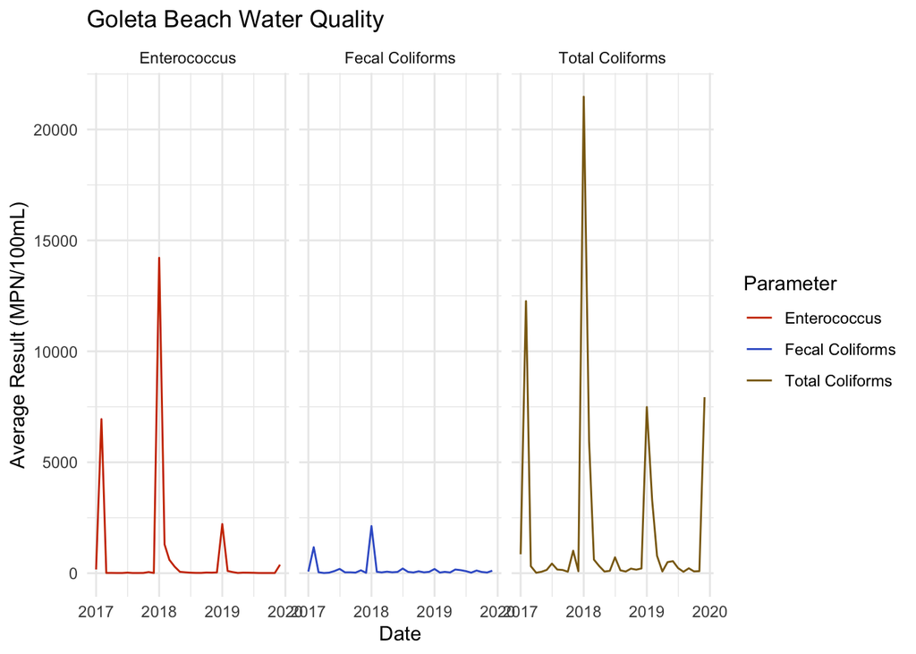

```r
## save plot
# ggsave(here(output_dir, "monthly_avg_gb_total_plot.png"), plot = monthly_avg_gb_total_plot)

# plot the monthly average results for 2017-2019
monthly_avg_gb_total_plot_2017_2019 <- monthly_avg_gb_total_mdy %>%
  filter(year %in% 2017:2019) %>%
  ggplot(aes(x = date, y = avg_result, color = parameter)) +
  scale_y_continuous(breaks=seq(0,20000,5000)) +
  scale_color_manual(values = c("Enterococcus" = "orangered3",
                               "Fecal Coliforms" = "royalblue3",
                               "Total Coliforms" = "goldenrod4")) +
  geom_line() +
  facet_wrap(~parameter) +
  labs(title = "Goleta Beach Water Quality",
       x = "Date",
       y = "Average Result (MPN/100mL)",
       color = "Parameter") +
  theme_minimal()
monthly_avg_gb_total_plot_2017_2019
```

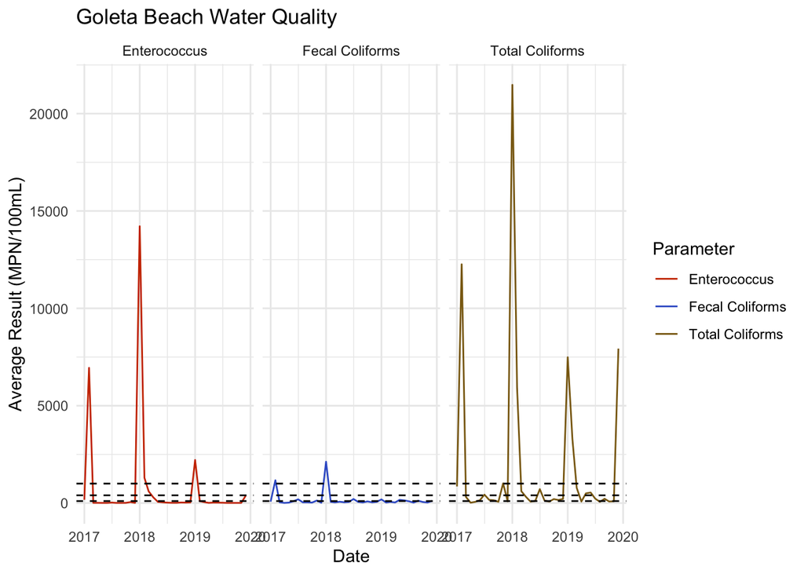

```r
# Add threshold lines with distinct colors
monthly_avg_gb_total_plot_2017_2019 +
  geom_hline(yintercept = 104, linetype = "dashed", color = "black", size = 0.5) +  # Dark gray
  geom_hline(yintercept = 400, linetype = "dashed", color = "black", size = 0.5) +  # Pink
  geom_hline(yintercept = 1000, linetype = "dashed", color = "black", size = 0.5)   # Orange
```

### Enterococcus Levels

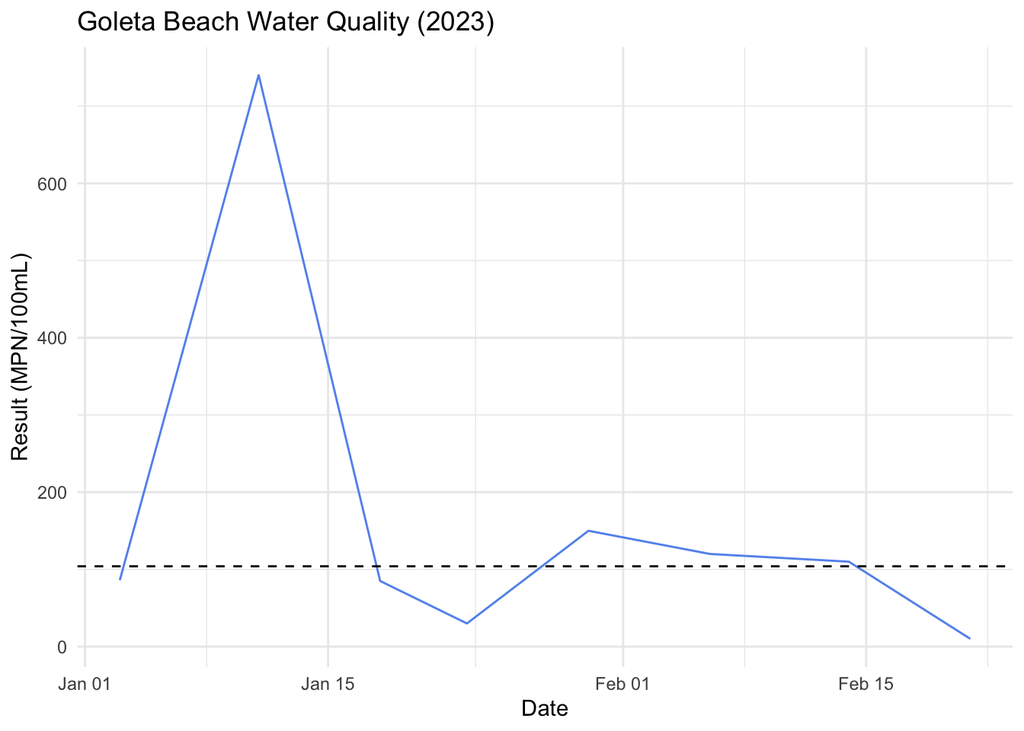

```r
# only enterococcus plot for 2023 in january and february
goleta_beach_qual_mdy %>%
  filter(parameter %in% "Enterococcus") %>%
  filter(year(sample_date) %in% 2023) %>%
  filter(month(sample_date) %in% 1:2) %>%
  ggplot(aes(x = sample_date, y = result)) +
  geom_line(color = "cornflowerblue") +
  labs(title = "Goleta Beach Water Quality (2023)",
       x = "Date",
       y = "Result (MPN/100mL)") +
  geom_hline(yintercept = 104, linetype = "dashed", color = "black", size = 0.5) + # criteria for enterococcus.  State Health Standard: Based on a single sample, the density of bacteria in water from each sampling station at a public beach or public water contact sports area shall not exceed: 104
  theme_minimal()
```

```r
# determine how many days on average in january and february have enterococcus levels above 104 MPN/100mL
days_exceeded_ent <- goleta_beach_qual_mdy %>%
  filter(parameter %in% "Enterococcus") %>%
  filter(month(sample_date) %in% 1:2) %>% # filter for jan and feb
  mutate(above_threshold = ifelse(result > 104, 1, 0)) %>% # state health criteria
  group_by(year(sample_date), month(sample_date)) %>% # group by year and month
  summarize(proportion_of_month_exceeded = as.numeric(sum(above_threshold)/n())) %>%  # proportion of days in the month that exceeded the threshold
  mutate(percent_of_month_exceeded = proportion_of_month_exceeded * 100) # convert to percentage

# make a table of the results
library(kableExtra)

table_days_exceeded <- days_exceeded_ent %>%
  select(year = `year(sample_date)`, month = `month(sample_date)`, percent_of_month_exceeded) %>% # select columns and rename
  knitr::kable() %>%
  kableExtra::kable_styling() # make prettier
table_days_exceeded
```

| year | month | percent_of_month_exceeded |
| --- | --- | --- |
| 2011 | 2 | 0.00000 |
| 2013 | 1 | 0.00000 |
| 2013 | 2 | 0.00000 |
| 2014 | 1 | 40.00000 |
| 2014 | 2 | 0.00000 |
| 2015 | 1 | 40.00000 |
| 2015 | 2 | 0.00000 |
| 2016 | 1 | 0.00000 |
| 2016 | 2 | 0.00000 |
| 2017 | 1 | 40.00000 |
| 2017 | 2 | 75.00000 |
| 2018 | 1 | 100.00000 |
| 2018 | 2 | 87.50000 |
| 2019 | 1 | 50.00000 |
| 2019 | 2 | 20.00000 |
| 2020 | 1 | 0.00000 |
| 2020 | 2 | 0.00000 |
| 2021 | 1 | 20.00000 |
| 2021 | 2 | 20.00000 |
| 2022 | 1 | 0.00000 |
| 2022 | 2 | 25.00000 |
| 2023 | 1 | 40.00000 |
| 2023 | 2 | 66.66667 |
| 2024 | 1 | 0.00000 |
| 2024 | 2 | 80.00000 |

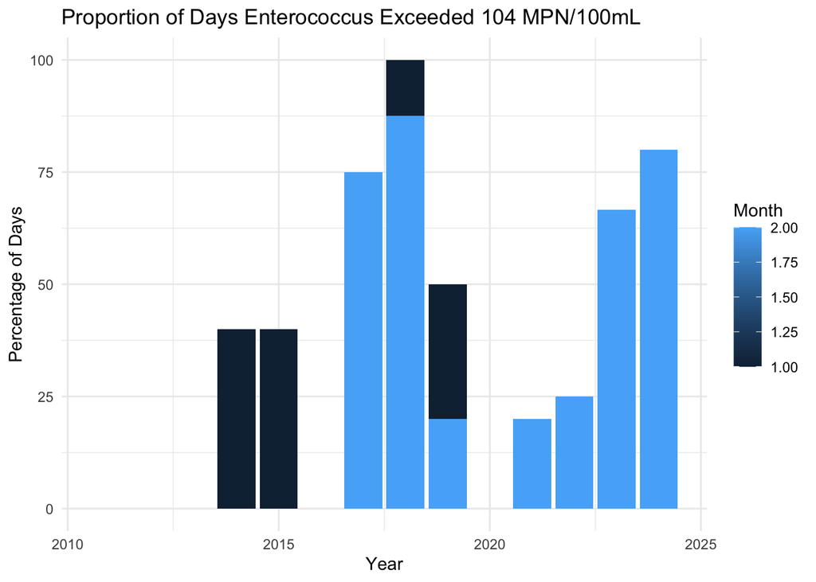

```r
# plot the results as a bar chart by year
days_exceeded_ent_plot <- days_exceeded_ent %>%
  rename(year = `year(sample_date)`, month = `month(sample_date)`) %>%
  ggplot(aes(x = year, y = percent_of_month_exceeded, fill = month)) +
  geom_bar(stat = "identity", position = "dodge") +
  theme_minimal() +
  labs(title = "Proportion of Days Enterococcus Exceeded 104 MPN/100mL",
       x = "Year",
       y = "Percentage of Days",
       fill = "Month")
days_exceeded_ent_plot
```

```r
# average percentage of days exceeded for january and february across all years
avg_exceeded_ent <- mean(days_exceeded_ent$percent_of_month_exceeded, na.rm = TRUE)
avg_exceeded_ent # 28.16667% of both months!
```

```
[1] 28.16667
```

# Value lost if 28% of days in January and February are above the threshold

```r
# calculate the value lost if 28% of days in January and February are above the threshold

days_lost_jan_feb <- 0.28 * 59 # average of 17 days the beach is unsuitable for swimming in january and february
days_lost_jan_feb # 16.52 days lost
```

```
[1] 16.52
```

```r
value_lost <- days_lost_jan_feb * consumer_surplus_daily # 28% of days in january and february times the value of the visit for each of those days is the value of the days lost
value_lost # $62.0382 lost in value per person
```

```
[1] 62.0382
```

Based on BEACON, there are 500,000 person-days per year at Goleta Beach, which means there are 500,000 visits every year. Therefore, we our value of daily consumer surplus is the value of one person-day.

```r
# based on 500,000 person-days a year visit GB from BEACON:
value_per_year <- consumer_surplus_daily*500000
value_per_year # $1,877,669 per year
```

```
[1] 1877669
```

```r
# value for two months of the year (jan and feb):
jan_feb_value_visitor_frequency <- value_per_year * (2/12) # two months of 12 months
jan_feb_value_visitor_frequency # $312,944.9
```

```
[1] 312944.9
```

```r
# value lost if 28% of days in January and February are above the threshold
value_lost_jan_feb_w_frequency <- jan_feb_value_visitor_frequency * 0.28
value_lost_jan_feb_w_frequency # $87,624.58 lost in value!
```

```
[1] 87624.58
```

We think this method is robust, as has similar values to another economic analysis via BEACON that values recreation for Santa Barbara County beaches. Our values are fairly similar to theirs, despite the fact that we used simulated data.